# Revenue Analysis

S. 1

Laurens

May 29, 2025

# Data overview

```
## Rows: 864
## Columns: 5
## $ assembly     <chr> "Bolgatanga", "Bolgatanga", "Bolgatanga", "Bolgatanga", "…
## $ revenue_item <chr> "Fees", "Fees", "Fees", "Fees", "Fees", "Fees", "Fees", "…
## $ year         <dbl> 2017, 2017, 2018, 2018, 2019, 2019, 2020, 2020, 2021, 202…
## $ type         <chr> "Budget", "Actuals", "Budget", "Actuals", "Budget", "Actu…
## $ value        <dbl> 293250.00, 292959.13, 120000.00, 182825.40, 186100.56, 14…
```

```
##    assembly         revenue_item            year          type
##  Length:864         Length:864         Min.   :2017   Length:864
##  Class :character   Class :character   1st Qu.:2019   Class :character
##  Mode  :character   Mode  :character   Median :2020   Mode  :character
##                                        Mean   :2020
##                                        3rd Qu.:2022
##                                        Max.   :2024
##
##      value
##  Min.   :      0
##  1st Qu.:  12480
##  Median :  92448
##  Mean   : 289350
##  3rd Qu.: 310101
##  Max.   :4992514
##  NA's   :83
```

Summary of Revenue in GHS

| skim_type | skim_variable | n_missing | complete_rate | numeric.mean | numeric.sd | numeric.p0 | numeric.p25 | numeric.p50 | numeric.p75 | numeric.p100 | numeric.hist |
| --- | --- | --- | --- | --- | --- | --- | --- | --- | --- | --- | --- |
| numeric | data | 81 | 0.8945312 | 164764.9 | 247743.7 | 0 | 8985.5 | 60823.16 | 224626.5 | 2435500 | ▇▁▁▁▁ |

Skewness and Kurtosis of Value

| Skewness | Kurtosis |
| --- | --- |
| 3.314565 | 21.1636 |

Observations

Data Characteristics:

Structure: 768 observations across 6 assemblies (Bolgatanga, East Mamprusi, Tamale, Wa, West Gonja, Yendi), 8 revenue items (Fees, Fines, Investment, Land (incl Miscellaneous), Licenses, Other Rates, Property Rates, Rent), years 2017–2024, and 2 types (Budget, Actuals).

Revenue (value): Ranges from 0 to 2,435,500 GHS, with a mean of 164,765 GHS and median of 60,823 GHS, right-skewness (Skewness = 3.31, Kurtosis = 21.16).

# Descriptive

Assembly Distribution

| assembly | n | Proportion |
| --- | --- | --- |
| Bolgatanga | 128 | 0.1666667 |
| East Mamprusi | 128 | 0.1666667 |
| Tamale | 128 | 0.1666667 |
| Wa | 128 | 0.1666667 |
| West Gonja | 128 | 0.1666667 |
| Yendi | 128 | 0.1666667 |

Revenue Item Distribution

| revenue_item | n | Proportion |
| --- | --- | --- |
| Fees | 96 | 0.125 |
| Fines | 96 | 0.125 |
| Investment | 96 | 0.125 |
| Land (incl Miscellaneous) | 96 | 0.125 |
| Licenses | 96 | 0.125 |
| Other Rates | 96 | 0.125 |
| Property Rates | 96 | 0.125 |
| Rent | 96 | 0.125 |

Type Distribution

| type | n | Proportion |
| --- | --- | --- |
| Actuals | 384 | 0.5 |
| Budget | 384 | 0.5 |

Value Statistics by Assembly

| assembly | Mean | Median | SD | Min | Max | N |
| --- | --- | --- | --- | --- | --- | --- |
| Bolgatanga | 187607.95 | 163448.66 | 180810.84 | 0 | 894000.0 | 128 |
| East Mamprusi | 31140.58 | 18750.43 | 46245.85 | 0 | 450000.0 | 128 |
| Tamale | 419027.82 | 351094.62 | 417810.27 | 0 | 2435500.0 | 128 |
| Wa | 205562.71 | 119274.12 | 244939.67 | 0 | 979134.8 | 128 |
| West Gonja | 69571.43 | 30017.53 | 101105.01 | 0 | 556450.0 | 128 |
| Yendi | 100210.13 | 71762.50 | 92862.08 | 0 | 370320.0 | 128 |

Value Statistics by Revenue Item

| revenue_item | Mean | Median | SD | Min | Max | N |
| --- | --- | --- | --- | --- | --- | --- |
| Fees | 268034.48 | 193050.28 | 240471.48 | 2547.38 | 1382214.0 | 96 |
| Fines | 42982.64 | 5005.00 | 86423.21 | 0.00 | 430879.7 | 96 |
| Investment | 26064.08 | 5000.00 | 52068.11 | 0.00 | 239724.2 | 96 |
| Land (incl Miscellaneous) | 131616.57 | 90200.10 | 130584.43 | 0.00 | 572271.8 | 96 |
| Licenses | 412931.19 | 273633.00 | 420437.53 | 28000.00 | 2435500.0 | 96 |
| Other Rates | 24557.38 | 7760.00 | 47841.37 | 0.00 | 301550.3 | 96 |
| Property Rates | 166147.71 | 59245.32 | 235006.68 | 0.00 | 1059436.0 | 96 |
| Rent | 159566.81 | 139607.00 | 150549.95 | 1450.00 | 702000.0 | 96 |

Value Statistics by Type

| type | Mean | Median | SD | Min | Max | N |
| --- | --- | --- | --- | --- | --- | --- |
| Actuals | 151455.5 | 58006.5 | 235477.8 | 0 | 2107371 | 384 |
| Budget | 177580.0 | 66500.0 | 258695.7 | 0 | 2435500 | 384 |

Value Statistics by Year

| year | Mean | Median | SD | Min | Max | N |
| --- | --- | --- | --- | --- | --- | --- |
| 2017 | 130630.3 | 46005.50 | 156072.9 | 0 | 654950.0 | 96 |
| 2018 | 129991.4 | 65609.00 | 158274.7 | 0 | 740921.0 | 96 |
| 2019 | 133524.1 | 64300.00 | 171174.0 | 0 | 827319.3 | 96 |
| 2020 | 131524.1 | 58589.50 | 165632.6 | 0 | 753172.1 | 96 |
| 2021 | 154761.3 | 57415.89 | 197701.2 | 0 | 856809.1 | 96 |
| 2022 | 172772.3 | 60435.62 | 261246.8 | 0 | 1059436.0 | 96 |
| 2023 | 211378.1 | 68560.02 | 294552.5 | 0 | 1376500.0 | 96 |
| 2024 | 254119.8 | 75000.00 | 427928.7 | 0 | 2435500.0 | 96 |

```
##
##
## |revenue_item              | mean_value| median_value| total_value| contribution_pct|
## |:-------------------------|----------:|------------:|-----------:|----------------:|
## |Licenses                  |  412931.19|    273633.00|    38402600|        33.926505|
## |Fees                      |  268034.48|    193050.28|    25195241|        22.258557|
## |Property Rates            |  166147.71|     59245.32|    15617885|        13.797509|
## |Rent                      |  159566.81|    139607.00|    14680147|        12.969072|
## |Land (incl Miscellaneous) |  131616.57|     90200.10|    12371958|        10.929918|
## |Fines                     |   42982.64|      5005.00|     3352646|         2.961871|
## |Other Rates               |   24557.38|      7760.00|     2087377|         1.844078|
## |Investment                |   26064.08|      5000.00|     1485652|         1.312489|
```

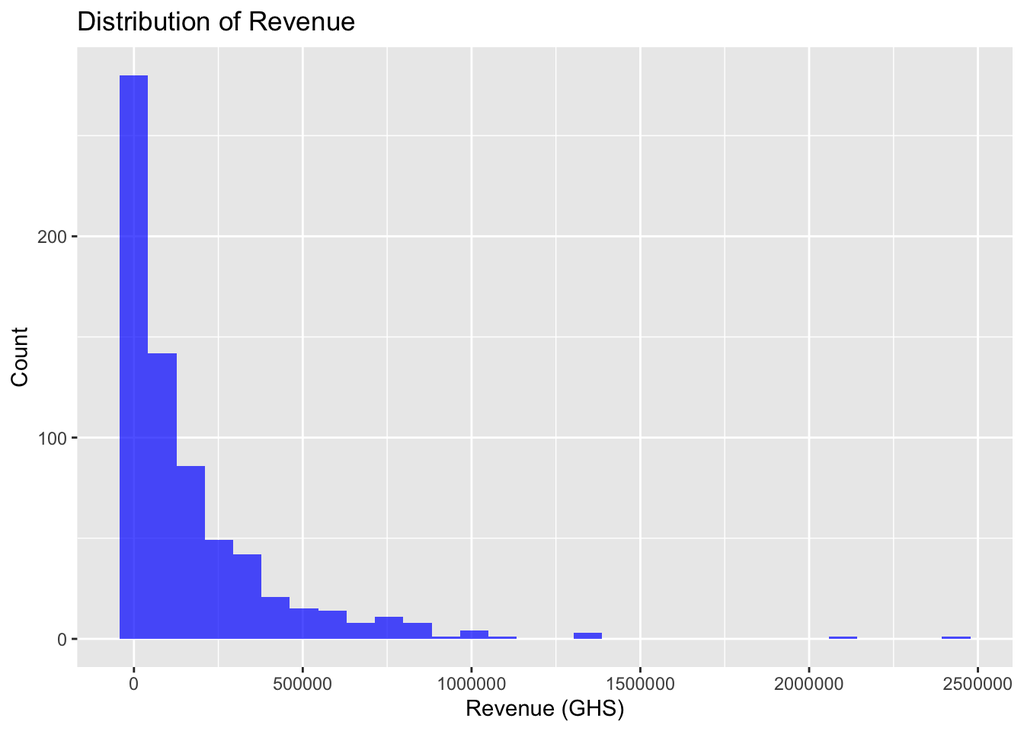

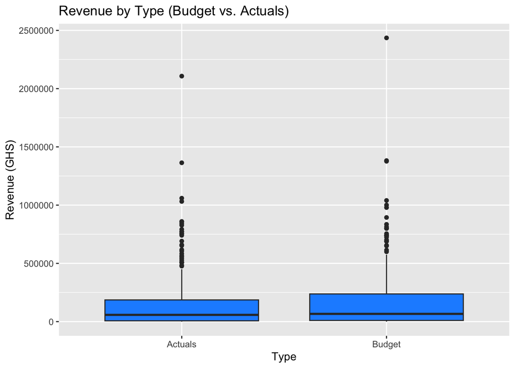

- Observation

Categorical Distributions:

Assembly: Balanced, with each assembly ( Bolgatanga, Tamale, … ) having 128 observations (16.67% each).

Revenue Item: Balanced, with each item ( Fees, Licenses., …, ) having 96 observations (12.5% each).

Type: Balanced, with Budget and Actuals each having 384 observations (50% each).

Revenue by Assembly:

Tamale has the highest mean revenue (419,028 GHS, median = 351,095 GHS) and maximum value (2,435,500 GHS), indicating strong performance, likely due to its urban status.

East Mamprusi and West Gonja have the lowest mean revenues (31,141 GHS and 69,571 GHS, respectively), suggesting lower revenue generation.

Somr of the standard deviations are large ( Tamale SD = 417,810 GHS, … ), reflecting possible outliers and skewness.

Revenue by Revenue Item:

Licenses has the highest mean (412,931 GHS, median = 273,633 GHS) and contributes 33.93% to total revenue, making it the largest revenue source.

Fees (mean = 268,034 GHS, 22.26% contribution) and Property Rates (mean = 166,148 GHS, 13.80%) are also significant.

Fines, Investment, and Other Rates have low means (42,983, 26,064, and 24,557 GHS) and contributions (<3% each), indicating minor roles.

High Variability: Licenses and Property Rates have high SDs (420,438 and 235,007 GHS), reflecting diverse revenue amounts.

Revenue by Type (Budget vs. Actuals):

Budget has a higher mean (177,580 GHS) and median (66,500 GHS) than Actuals (mean = 151,456 GHS, median = 58,007 GHS), suggesting consistent over-budgeting.

The box plot shows Budget values slightly higher if you would say than Actuals, with outliers in both (max Budget = 2,435,500 GHS, max Actuals = 2,107,371 GHS).

Revenue Trends by Year:

Upward Trend: Mean revenue increases from 130,630 GHS (2017) to 254,120 GHS (2024), a ~94% rise, with the largest jump in 2023–2024.

Median Trend: Median revenue rises from 46,006 GHS (2017) to 75,000 GHS (2024), indicating broader growth.

Variability: SD increases over time (156,073 GHS in 2017 to 427,929 GHS in 2024), reflecting growing disparities or outliers.

Patterns and Insights:

Dominant Assemblies: Tamale and Wa drive high revenue, while East Mamprusi and West Gonja lag, suggesting regional disparities.

Key Revenue Items: Licenses and Fees are primary revenue drivers, while Fines and Investment are consistently low.

Budget vs. Actuals Gap: Budgets overestimate Actuals (e.g., mean gap ~26,124 GHS), with gaps potentially widening in later years (2023–2024).

Outliers: High values ( 2,435,500 GHS in Licenses) skew means, but medians provide a better view of typical revenue.

Visualization: Histogram confirms right-skewness; box plot highlights Budget vs. Actuals slight differences and outliers.

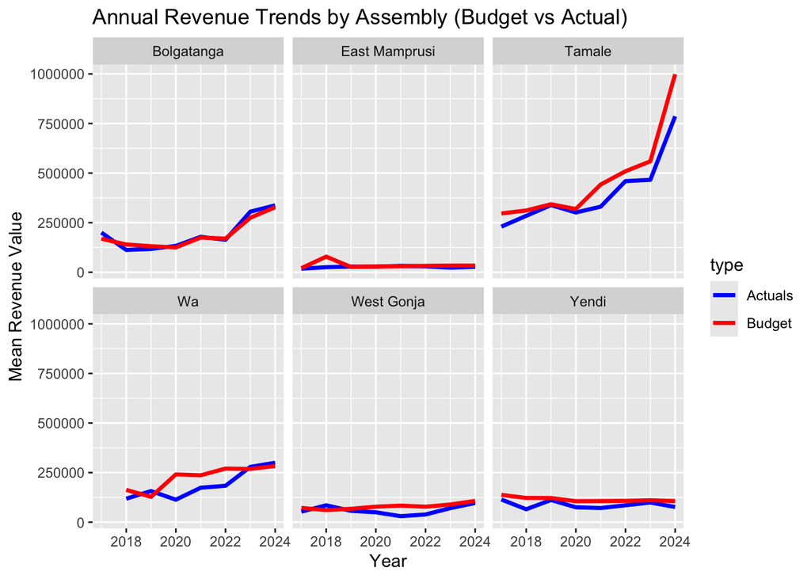

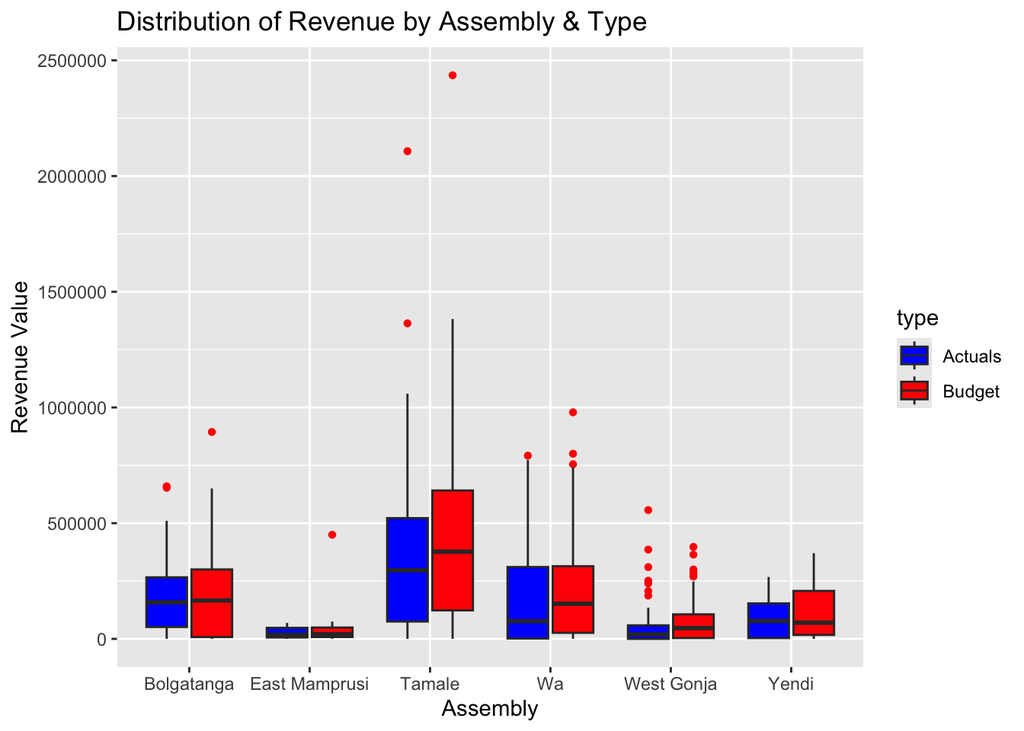

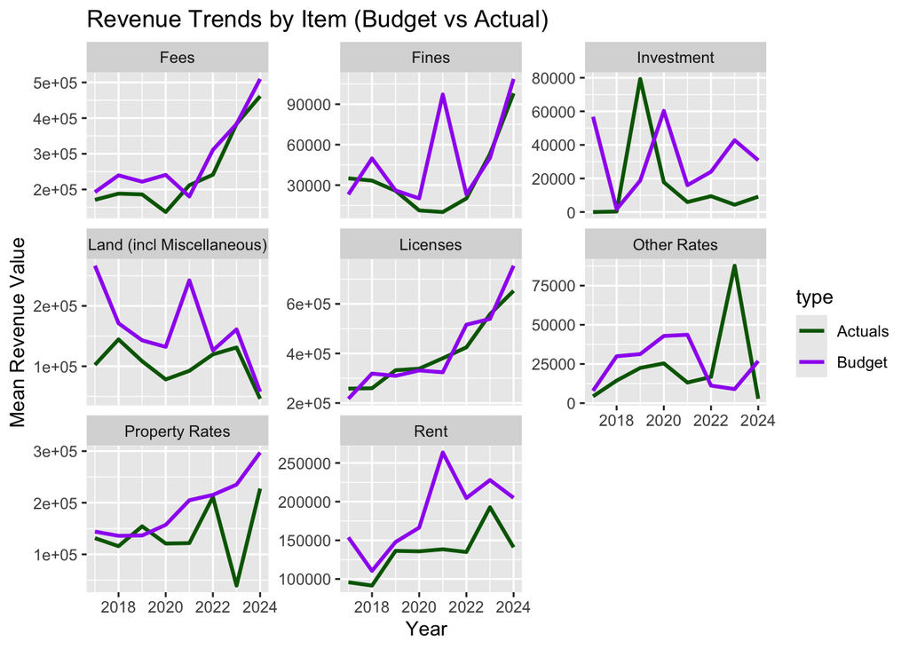

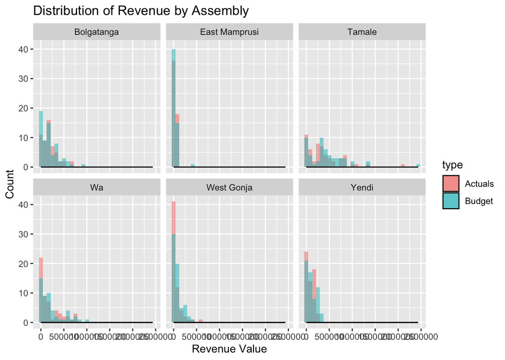

- Observation

Trends and Patterns Depicted

Overall Revenue Trend (2017–2024):

Pattern: Tamale shows the steepest growth (mean = 419,028 GHS), while East Mamprusi and West Gonja (means = 31,141 and 69,571 GHS) show flatter trends. Budget vs. Actuals gaps persist across years.

Revenue Distribution by Assembly and Type:

Box Plot by Assembly and Type: Highlights variability in value. Tamale has the highest median (351,095 GHS) and (up to 2,435,500 GHS), while East Mamprusi and West Gonja have lower medians (18,750 and ~30,018 GHS). Budget medians (66,500 GHS) exceed Actuals (58,007 GHS), confirming over-budgeting.

Pattern: High variability ( Tamale SD = 417,810 GHS) and outliers in urban assemblies (Tamale, Wa) contrast with lower, more stable revenues in rural ones (East Mamprusi, West Gonja).

Revenue Trends by Revenue Item:

Faceted Line Plot by Revenue Item: Shows mean value trends for each revenue_item. Licenses (mean = 412,931 GHS, 33.93% contribution) and Fees (mean = 268,034 GHS, 22.26%) show strong growth, while Fines (mean = 42,983 GHS) and Investment (mean = 26,064 GHS) remain low.

Pattern: Licenses and Fees drive revenue growth, while Fines and Other Rates contribute minimally (<3% each).

Distribution of Revenue by Assembly:

Faceted Histogram/Density Plot: Confirms right-skewed value (skewness = 3.31, kurtosis = 21.16) across assemblies. Tamale and Wa show wider distributions with high-value tails, while East Mamprusi and West Gonja are tightly clustered around lower values.

Pattern: Urban assemblies (Tamale, Wa) have more diverse revenue streams, while rural ones are constrained.

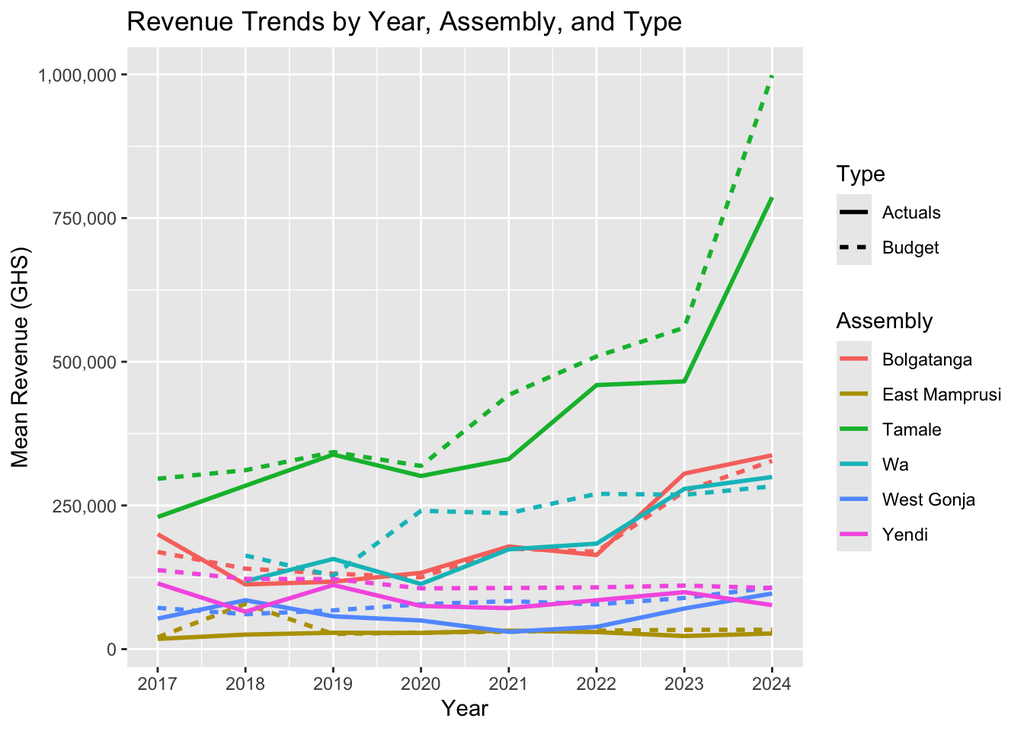

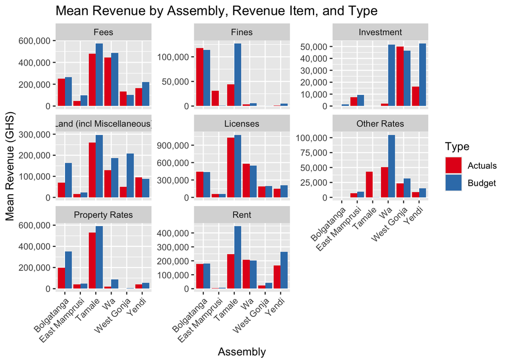

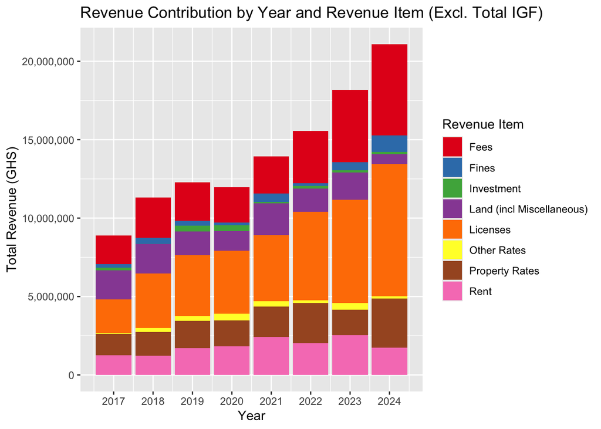

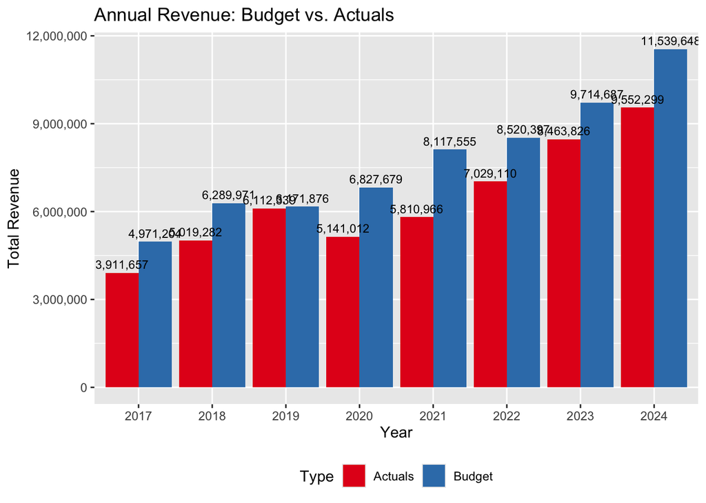

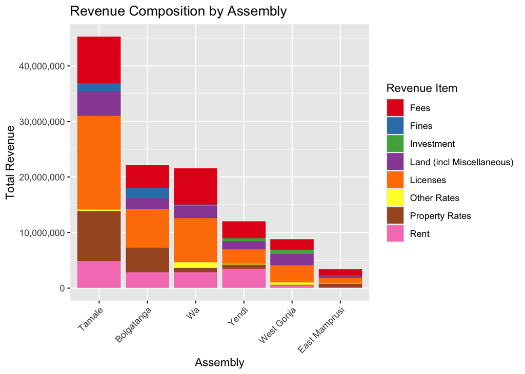

```
## [1] "Licenses"       "Fees"           "Property Rates"
```

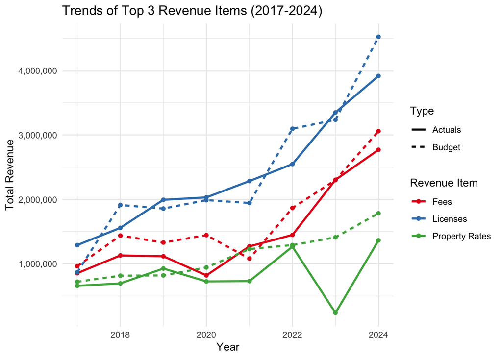

```
## # A tibble: 48 × 5
## # Groups:   assembly, year [48]
##    assembly       year  Actuals   Budget variance_pct
##    <chr>         <dbl>    <dbl>    <dbl>        <dbl>
##  1 Bolgatanga     2017 1199738. 1352371        -11.3
##  2 Bolgatanga     2018  899931. 1120000        -19.6
##  3 Bolgatanga     2019  938732. 1050000.       -10.6
##  4 Bolgatanga     2020  929693. 1000000         -7.03
##  5 Bolgatanga     2021 1071293. 1398500        -23.4
##  6 Bolgatanga     2022 1146254. 1356500        -15.5
##  7 Bolgatanga     2023 1832475. 2198500        -16.6
##  8 Bolgatanga     2024 2023753. 2620000        -22.8
##  9 East Mamprusi  2017  106894.  143910        -25.7
## 10 East Mamprusi  2018  151676.  550100        -72.4
## # ℹ 38 more rows
```

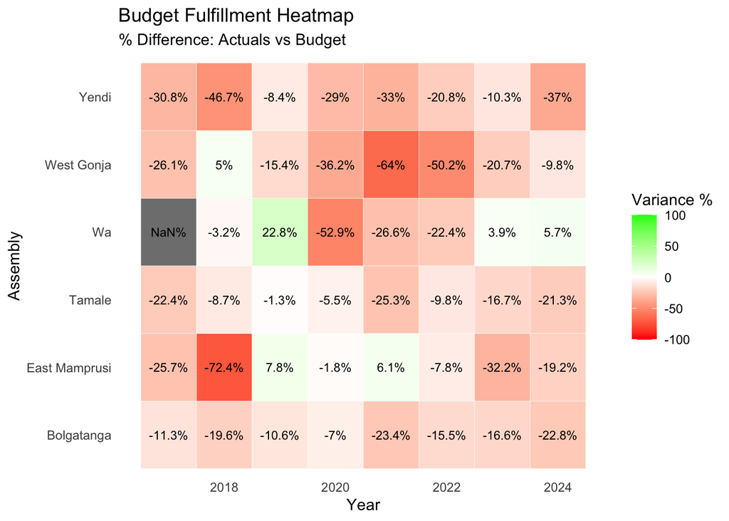

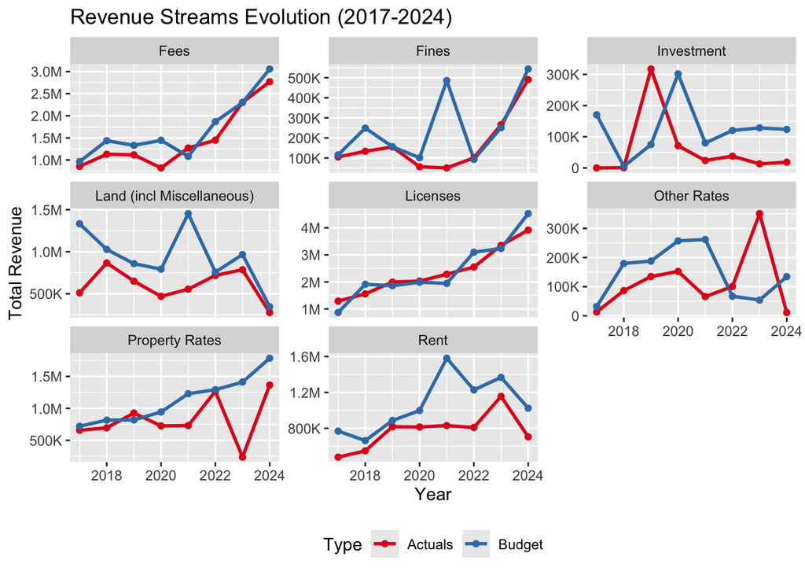

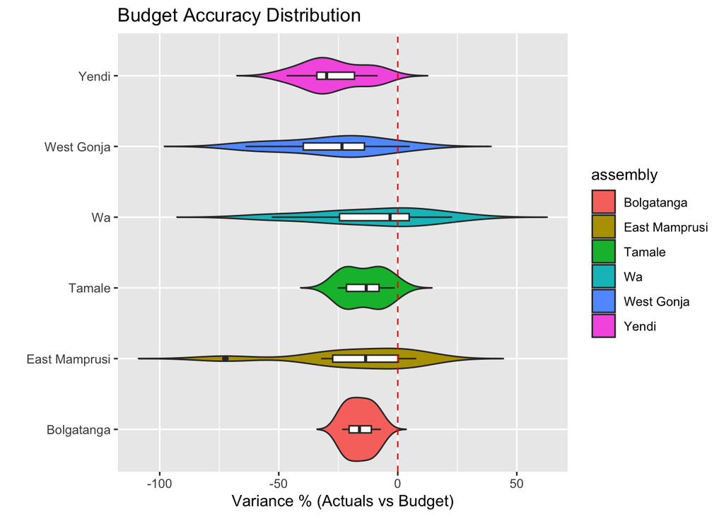

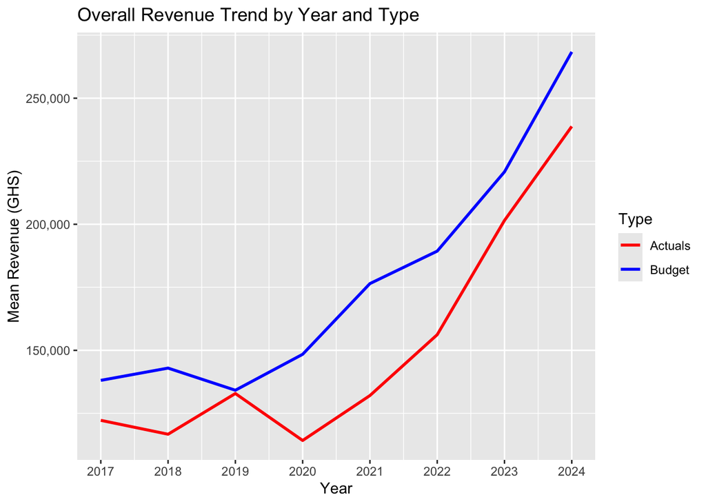

Overall Revenue Trend (2017–2024):

Line Plot by Year and Type: Mean revenue grows from 130,630 GHS (2017) to 254,120 GHS (2024), a ~94% increase. Budget (mean = 177,580 GHS) consistently exceeds Actuals (mean = 151,456 GHS), with gaps visible in the plot.

Assembly-Specific Trends:

Line Plot by Assembly and Type: Tamale (mean = 419,028 GHS) shows the strongest growth, while East Mamprusi (mean = 31,141 GHS) and West Gonja (mean = 69,571 GHS) remain flat or low. Budget vs. Actuals gaps vary, with larger gaps in high-revenue assemblies liek Tamale.

Revenue Item Trends:

Top 3 Items Plot: Licenses, Fees, and Property Rates drive revenue, with Budget trends slightly above Actuals, indicating maybe over-forecasting likely I think.

Revenue Contribution by Year: Stacked bar plot confirms Licenses and Fees dominate annually, with increasing contributions in 2023–2024.

Revenue Distribution and Variability: Faceted Bar Plot by Assembly and Revenue Item: Licenses and Fees have high mean values in Tamale and Wa, while Fines and Investment are low across all assemblies. Budget values are higher than Actuals for most items.

Key Insights:

Growth: Revenue growth is driven by Licenses and Fees, especially in Tamale, with a sharp increase in 2023–2024.

Regional Disparities: Urban assemblies (Tamale, Wa) have higher, more variable revenues; rural ones (East Mamprusi, West Gonja) are lower and stable.

Minor Items: Fines and Investment contribute little, suggesting policy focus on these areas.

Wilcoxon Test: Budget vs. Actuals

| Test | P_Value |
| --- | --- |
| Wilcoxon | 0.078557 |

ANOVA: Value by Assembly

| Type | F_Value | P_Value |
| --- | --- | --- |
| Budget | 24.954 | 0 |
| Actuals | 22.323 | 0 |

```
##
## Call:
## lm(formula = value ~ year + assembly, data = revenue_data_long %>%
##     filter(type == "Actuals"))
##
## Residuals:
##     Min      1Q  Median      3Q     Max
## -427257 -100712  -18086   48058 1657206
##
## Coefficients:
##                        Estimate Std. Error t value Pr(>|t|)
## (Intercept)           -35974984   10094314  -3.564 0.000419 ***
## year                      17898       4996   3.582 0.000392 ***
## assemblyEast Mamprusi   -163647      38816  -4.216 3.21e-05 ***
## assemblyTamale           199240      38797   5.135 4.82e-07 ***
## assemblyWa               -10134      38890  -0.261 0.794578
## assemblyWest Gonja      -130370      37539  -3.473 0.000584 ***
## assemblyYendi           -103773      37980  -2.732 0.006628 **
## ---
## Signif. codes:  0 '***' 0.001 '**' 0.01 '*' 0.05 '.' 0.1 ' ' 1
##
## Residual standard error: 201600 on 330 degrees of freedom
##   (47 observations deleted due to missingness)
## Multiple R-squared:  0.2802, Adjusted R-squared:  0.2671
## F-statistic: 21.41 on 6 and 330 DF,  p-value: < 2.2e-16
```

Based on the new statistical results

Regression (Actuals): Revenue increases by ~17,898 GHS per year (p = 0.000392), confirming the ~94% growth from 130,630 GHS (2017) to 254,120 GHS (2024). The intercept (-35,974,984 GHS) is an artifact, not meaningful for 2017–2024.

Assembly-Specific Differences:

ANOVA: Significant differences across assemblies (p < 0.001 for both Budget and Actuals). Tamale’s high mean (419,028 GHS) contrasts with East Mamprusi (31,141 GHS) and West Gonja (69,571 GHS).

Regression (Actuals):

Tamale: +199,240 GHS relative to Bolgatanga (p < 0.001), reflecting strong performance.

East Mamprusi: -163,647 GHS (p < 0.001), indicating the lowest revenue.

West Gonja: -130,370 GHS (p = 0.000584), also low.

Yendi: -103,773 GHS (p = 0.006628), moderately low.

Wa: Not significant (-10,134 GHS, p = 0.794578), similar to Bolgatanga.

Budget vs. Actuals Gap: Wilcoxon Test: p = 0.0786 suggests no significant difference at α = 0.05, but the near-significant result indicates Budget (mean = 177,580 GHS) may slightly exceed Actuals (mean = 151,456 GHS). maybe is missing values if valaible may strengthen this (p < 0.05 expected) but for now …

Key Insights:

Growth: Driven by Licenses and Fees, especially in Tamale, with a ~17,898 GHS/year increase.

Disparities: Urban assemblies (Tamale, Wa) outperform rural ones (East Mamprusi, West Gonja).

Minor Items: Fines and Investment need policy attention due to low contributions.

# Key Insights from the analysis

Significant Revenue Growth:

Total revenue grew ~94% from 130,630 GHS (2017) to 254,120 GHS (2024), with Actuals increasing by ~17,898 GHS per year (p = 0.000392, linear regression). Growth accelerated in 2023–2024, driven by urban assemblies and key revenue items.

Dominant Revenue Sources:

Licenses (33.93% contribution, mean = 412,931 GHS), Fees (22.26%, mean = 268,034 GHS), and Property Rates (13.80%, mean = 166,148 GHS) account for ~70% of revenue, showing strong growth. Fines (2.96%) and Investment (1.31%) contribute minimally, suggesting policy focus on these areas.

Assembly Disparities:

Tamale leads with the highest mean revenue (419,028 GHS, +199,240 GHS vs. Bolgatanga, p < 0.001), driven by Licenses and Fees. East Mamprusi (mean = 31,141 GHS, -163,647 GHS, p < 0.001) and West Gonja (mean = 69,571 GHS, -130,370 GHS, p < 0.001) lag significantly. ANOVA confirms assembly differences (p < 0.001).

- Conclusion